# Applied Exercises for Chapter 3

Jean Cochrane

7 September 2018

## Exercise 8

This question involves the use of simple linear regression on the `Auto` dataset.

### Exercise 8a.

Use the `lm()` function to perform a simple linear regression with `mpg` as the response and `horsepower` as the predictor. Use the `summary()` function to print the results. Comment on the output. For example:

1. Is there a relationship between the predictor and the response?
2. How strong is the relationship between the predictor and the response?
3. Is the relationship between the predictor and the response positive or negative?
4. What is the predicted `mpg` associated with a `horsepower` of 98? What are the associated 95% confidence and prediction intervals?

### Answer 8a.

Use `lm` to regress `mpg` on `horsepower`:

```r
# Load the Auto dataset.
library(ISLR)

# Regress MPG on horsepower.
model = lm(mpg~horsepower, data=Auto)
summary(model)
```

```
##
## Call:
## lm(formula = mpg ~ horsepower, data = Auto)
##
## Residuals:
##      Min       1Q   Median       3Q      Max
## -13.5710  -3.2592  -0.3435   2.7630  16.9240
##
## Coefficients:
##              Estimate Std. Error t value Pr(>|t|)
## (Intercept) 39.935861   0.717499   55.66   <2e-16 ***
## horsepower  -0.157845   0.006446  -24.49   <2e-16 ***
## ---
## Signif. codes:  0 '***' 0.001 '**' 0.01 '*' 0.05 '.' 0.1 ' ' 1
##
## Residual standard error: 4.906 on 390 degrees of freedom
## Multiple R-squared:  0.6059, Adjusted R-squared:  0.6049
## F-statistic: 599.7 on 1 and 390 DF,  p-value: < 2.2e-16
```

As the results show, there is indeed a relationship between `horsepower` and `mpg`. The `horsepower` coefficient is around -0.158, meaning that a one-unit increase in horsepower corresponds to about 0.15 *fewer* miles per gallon. (This makes sense, as we would predict that a more powerful engine might be less efficient.) The relationship is quite significant, with a p-value < 0.001.

Note that while the relationship exists, however, it is not terribly strong. Our R-squared reports that `horsepower` accounts for only about 60% of the variance of `mpg`. There are likely other factors with a substantial impact on `mpg`, although `horsepower` does an OK job approximating the effect.

We can get a predicted confidence interval for a `horsepower` of 98 using the `predict` method:

```r
predict(model, data.frame(horsepower=c(98)), interval="confidence")
```

```
##        fit      lwr      upr
## 1 24.46708 23.97308 24.96108
```

The model predicts a value for `mpg` of 24.47, with 95% confidence that the true value lies in the range `[23.97, 24.96]`.

`predict` also allows us to generate a prediction interval:

```r
predict(model, data.frame(horsepower=c(98)), interval="prediction")
```

```
##        fit     lwr      upr
## 1 24.46708 14.8094 34.12476
```

In this case, taking into account an estimate for the irreducible error in the data, the model predicts a range of `[14.81, 34.12]` – there’s quite a lot of noise in the data!

## Exercise 8b.

Plot the response and the predictor. Use the `abline()` function to display the least squares regression line.

## Answer 8b.

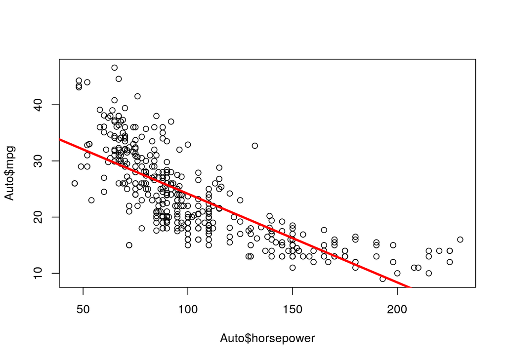

```r
plot(Auto$horsepower, Auto$mpg)
abline(model, lwd=3, col="red")
```

From this plot, there’s a pretty good indication that the true effect is nonlinear.

## Exercise 8c.

Use the `plot()` function to produce diagnostic plots of the least squres regresion fit. Comment on any problems you see with the fit.

## Answer 8c.

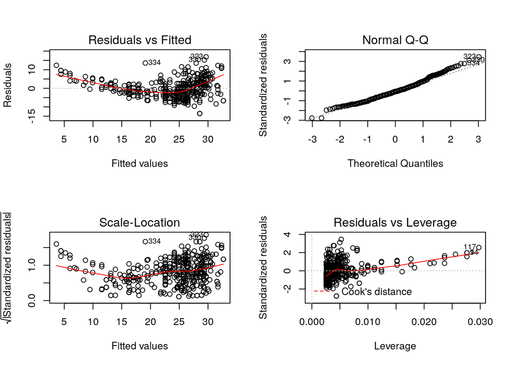

```r
par(mfrow=c(2,2))
plot(model)
```

The `Residuals vs Fitted` plot clearly shows that there’s a pattern to the residuals, confirming that the model is not linear.

## Exercise 9

This question involves the use of simple linear regression on the `Auto` dataset.

### Exercise 9a.

Produce a scatterplot matrix which includes all of the variables in the data set.

### Answer 9a.

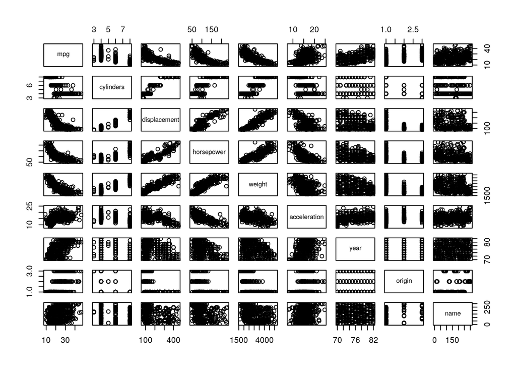

```r
pairs(Auto)
```

### Exercise 9b.

Compute the matrix of correlations between the variables using the function `cor()`. You will need to exclude the `name` variable, which is qualitative.

### Answer 9b.

```r
cor(subset(Auto, select=-name))
```

```
##                     mpg  cylinders displacement horsepower     weight
## mpg           1.0000000 -0.7776175   -0.8051269 -0.7784268 -0.8322442
## cylinders    -0.7776175  1.0000000    0.9508233  0.8429834  0.8975273
## displacement -0.8051269  0.9508233    1.0000000  0.8972570  0.9329944
## horsepower   -0.7784268  0.8429834    0.8972570  1.0000000  0.8645377
## weight       -0.8322442  0.8975273    0.9329944  0.8645377  1.0000000
## acceleration  0.4233285 -0.5046834   -0.5438005 -0.6891955 -0.4168392
## year          0.5805410 -0.3456474   -0.3698552 -0.4163615 -0.3091199
## origin        0.5652088 -0.5689316   -0.6145351 -0.4551715 -0.5850054
##              acceleration       year     origin
## mpg             0.4233285  0.5805410  0.5652088
## cylinders      -0.5046834 -0.3456474 -0.5689316
## displacement   -0.5438005 -0.3698552 -0.6145351
## horsepower     -0.6891955 -0.4163615 -0.4551715
## weight         -0.4168392 -0.3091199 -0.5850054
## acceleration    1.0000000  0.2903161  0.2127458
## year            0.2903161  1.0000000  0.1815277
## origin          0.2127458  0.1815277  1.0000000
```

### Exercise 9c.

Use the `lm()` function to perform a multiple linear regression with `mpg` as the response and all other variables except `name` as the predictors. Use the `summary()` function to print the results. Comment on the output. For instance:

1. Is there a relationship between the predictors and the response?
2. Which predictors appear to have a statistically significant relationship to the response?
3. What does the coefficient for the `year` variable suggest?

### Answer 9c.

```r
lm.fit = lm(mpg~.-name, data=Auto)
summary(lm.fit)
```

```
##
## Call:
## lm(formula = mpg ~ . - name, data = Auto)
##
## Residuals:
##     Min      1Q  Median      3Q     Max
## -9.5903 -2.1565 -0.1169  1.8690 13.0604
##
## Coefficients:
##                Estimate Std. Error t value Pr(>|t|)
## (Intercept)  -17.218435   4.644294  -3.707  0.00024 ***
## cylinders     -0.493376   0.323282  -1.526  0.12780
## displacement   0.019896   0.007515   2.647  0.00844 **
## horsepower    -0.016951   0.013787  -1.230  0.21963
## weight        -0.006474   0.000652  -9.929  < 2e-16 ***
## acceleration   0.080576   0.098845   0.815  0.41548
## year           0.750773   0.050973  14.729  < 2e-16 ***
## origin         1.426141   0.278136   5.127 4.67e-07 ***
## ---
## Signif. codes:  0 '***' 0.001 '**' 0.01 '*' 0.05 '.' 0.1 ' ' 1
##
## Residual standard error: 3.328 on 384 degrees of freedom
## Multiple R-squared:  0.8215, Adjusted R-squared:  0.8182
## F-statistic: 252.4 on 7 and 384 DF,  p-value: < 2.2e-16
```

1. There is a relationship between the predictors and the response: the F-statistic renders a p-value very close to 0.
2. `displacement`, `weight`, `year`, and `origin` all have significant relationships to the response (`p < 0.05`).
3. The coefficient for `year` is `~ 0.751`, which indicates that newer cars have better MPG (and vice versa).

### Exercise 9d.

Use the `plot()` function to produce diagnostic plots of the linear regression fit. Comment on any problems you see with the fit. Do the residual plots suggest and unusually large outliers? Does the leverage plot identify any observations with unusually high leverage?

### Answer 9d.

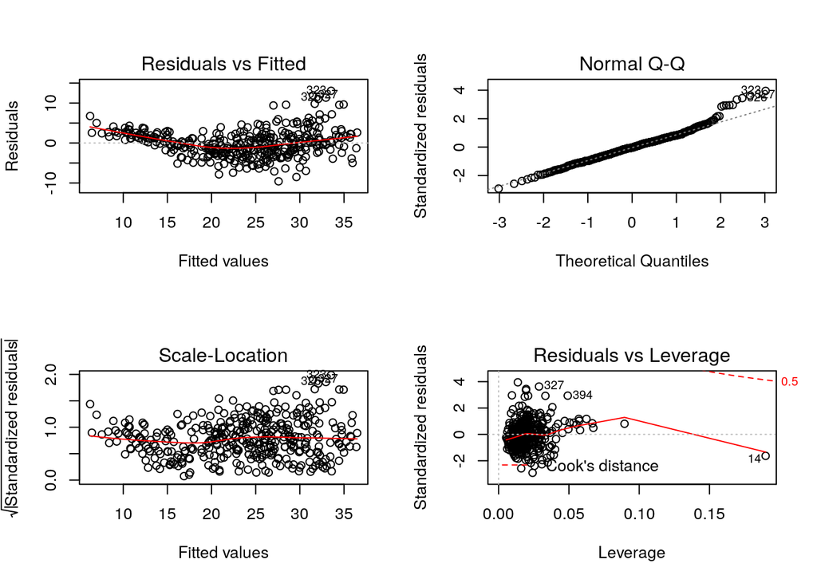

```r
par(mfrow=c(2,2))
plot(lm.fit)
```

### Exercise 9e.

Use the `*` and `:` symbols to fit linear regression models with interaction effects. Do any interactions appear to be statistically significant?

### Answer 9e.

Looking at the pairwise correlation matrix produced in answer 9b, a few correlations are high enough to merit investigating interaction effects:

- `displacement:cylinders`
- `displacement:weight`
- `displacement:horsepower`
- `cylinders:weight`
- `cylinders:horsepower`
- `cylinders:weight`

```r
summary(lm(mpg ~ displacement*cylinders, data=Auto))
```

```
##
## Call:
## lm(formula = mpg ~ displacement * cylinders, data = Auto)
##
## Residuals:
##      Min       1Q   Median       3Q      Max
## -16.0432  -2.4308  -0.2263   2.2048  20.9051
##
## Coefficients:
##                        Estimate Std. Error t value Pr(>|t|)
## (Intercept)            48.22040    2.34712  20.545  < 2e-16 ***
## displacement           -0.13436    0.01615  -8.321 1.50e-15 ***
## cylinders              -2.41838    0.53456  -4.524 8.08e-06 ***
## displacement:cylinders  0.01182    0.00207   5.711 2.24e-08 ***
## ---
## Signif. codes:  0 '***' 0.001 '**' 0.01 '*' 0.05 '.' 0.1 ' ' 1
##
## Residual standard error: 4.454 on 388 degrees of freedom
## Multiple R-squared:  0.6769, Adjusted R-squared:  0.6744
## F-statistic:   271 on 3 and 388 DF,  p-value: < 2.2e-16
```

```r
summary(lm(mpg ~ displacement*weight, data=Auto))
```

```
##
## Call:
## lm(formula = mpg ~ displacement * weight, data = Auto)
##
## Residuals:
##      Min       1Q   Median       3Q      Max
## -13.8664  -2.4801  -0.3355   1.8071  17.9429
##
## Coefficients:
##                       Estimate Std. Error t value Pr(>|t|)
## (Intercept)          5.372e+01  1.940e+00  27.697  < 2e-16 ***
## displacement        -7.831e-02  1.131e-02  -6.922 1.85e-11 ***
## weight              -8.931e-03  8.474e-04 -10.539  < 2e-16 ***
## displacement:weight  1.744e-05  2.789e-06   6.253 1.06e-09 ***
## ---
## Signif. codes:  0 '***' 0.001 '**' 0.01 '*' 0.05 '.' 0.1 ' ' 1
##
## Residual standard error: 4.097 on 388 degrees of freedom
## Multiple R-squared:  0.7265, Adjusted R-squared:  0.7244
## F-statistic: 343.6 on 3 and 388 DF,  p-value: < 2.2e-16
```

```r
summary(lm(mpg ~ displacement*horsepower, data=Auto))
```

```
##
## Call:
## lm(formula = mpg ~ displacement * horsepower, data = Auto)
##
## Residuals:
##      Min       1Q   Median       3Q      Max
## -10.9391  -2.3373  -0.5816   2.1698  17.5771
##
## Coefficients:
##                           Estimate Std. Error t value Pr(>|t|)
## (Intercept)              5.305e+01  1.526e+00   34.77   <2e-16 ***
## displacement            -9.805e-02  6.682e-03  -14.67   <2e-16 ***
## horsepower              -2.343e-01  1.959e-02  -11.96   <2e-16 ***
## displacement:horsepower  5.828e-04  5.193e-05   11.22   <2e-16 ***
## ---
## Signif. codes:  0 '***' 0.001 '**' 0.01 '*' 0.05 '.' 0.1 ' ' 1
##
## Residual standard error: 3.944 on 388 degrees of freedom
## Multiple R-squared:  0.7466, Adjusted R-squared:  0.7446
## F-statistic:   381 on 3 and 388 DF,  p-value: < 2.2e-16
```

```r
summary(lm(mpg ~ cylinders*weight, data=Auto))
```

```
##
## Call:
## lm(formula = mpg ~ cylinders * weight, data = Auto)
##
## Residuals:
##      Min       1Q   Median       3Q      Max
## -14.4916  -2.6225  -0.3927   1.7794  16.7087
##
## Coefficients:
##                    Estimate Std. Error t value Pr(>|t|)
## (Intercept)      65.3864559  3.7333137  17.514  < 2e-16 ***
## cylinders        -4.2097950  0.7238315  -5.816 1.26e-08 ***
## weight           -0.0128348  0.0013628  -9.418  < 2e-16 ***
## cylinders:weight  0.0010979  0.0002101   5.226 2.83e-07 ***
## ---
## Signif. codes:  0 '***' 0.001 '**' 0.01 '*' 0.05 '.' 0.1 ' ' 1
##
## Residual standard error: 4.165 on 388 degrees of freedom
## Multiple R-squared:  0.7174, Adjusted R-squared:  0.7152
## F-statistic: 328.3 on 3 and 388 DF,  p-value: < 2.2e-16
```

```r
summary(lm(mpg ~ cylinders*horsepower, data=Auto))
```

```
##
## Call:
## lm(formula = mpg ~ cylinders * horsepower, data = Auto)
##
## Residuals:
##      Min       1Q   Median       3Q      Max
## -11.5862  -2.1945  -0.5617   1.9541  16.3329
##
## Coefficients:
##                       Estimate Std. Error t value Pr(>|t|)
## (Intercept)          72.815097   3.071314  23.708   <2e-16 ***
## cylinders            -6.492462   0.510560 -12.716   <2e-16 ***
## horsepower           -0.416007   0.034521 -12.051   <2e-16 ***
## cylinders:horsepower  0.047247   0.004732   9.984   <2e-16 ***
## ---
## Signif. codes:  0 '***' 0.001 '**' 0.01 '*' 0.05 '.' 0.1 ' ' 1
##
## Residual standard error: 4.094 on 388 degrees of freedom
## Multiple R-squared:  0.727,  Adjusted R-squared:  0.7249
## F-statistic: 344.4 on 3 and 388 DF,  p-value: < 2.2e-16
```

```r
summary(lm(mpg ~ horsepower*weight, data=Auto))
```

```
##
## Call:
## lm(formula = mpg ~ horsepower * weight, data = Auto)
##
## Residuals:
##      Min       1Q   Median       3Q      Max
## -10.7725  -2.2074  -0.2708   1.9973  14.7314
##
## Coefficients:
##                     Estimate Std. Error t value Pr(>|t|)
## (Intercept)        6.356e+01  2.343e+00  27.127  < 2e-16 ***
## horsepower        -2.508e-01  2.728e-02  -9.195  < 2e-16 ***
## weight            -1.077e-02  7.738e-04 -13.921  < 2e-16 ***
## horsepower:weight  5.355e-05  6.649e-06   8.054 9.93e-15 ***
## ---
## Signif. codes:  0 '***' 0.001 '**' 0.01 '*' 0.05 '.' 0.1 ' ' 1
##
## Residual standard error: 3.93 on 388 degrees of freedom
## Multiple R-squared:  0.7484, Adjusted R-squared:  0.7465
## F-statistic: 384.8 on 3 and 388 DF,  p-value: < 2.2e-16
```

```r
summary(lm(mpg ~ cylinders*displacement + cylinders*horsepower, data=Auto))
```

```
##
## Call:
## lm(formula = mpg ~ cylinders * displacement + cylinders * horsepower,
##     data = Auto)
##
## Residuals:
##      Min       1Q   Median       3Q      Max
## -11.7033  -2.2637  -0.5521   1.9784  17.7813
##
## Coefficients:
##                         Estimate Std. Error t value Pr(>|t|)
## (Intercept)            69.303711   3.094083  22.399  < 2e-16 ***
## cylinders              -5.188780   0.574606  -9.030  < 2e-16 ***
## displacement           -0.055996   0.020704  -2.705  0.00714 **
## horsepower             -0.357984   0.046980  -7.620 1.98e-13 ***
## cylinders:displacement  0.003645   0.003231   1.128  0.25997
## cylinders:horsepower    0.041996   0.007453   5.634 3.39e-08 ***
## ---
## Signif. codes:  0 '***' 0.001 '**' 0.01 '*' 0.05 '.' 0.1 ' ' 1
##
## Residual standard error: 3.995 on 386 degrees of freedom
## Multiple R-squared:  0.7414, Adjusted R-squared:  0.738
## F-statistic: 221.3 on 5 and 386 DF,  p-value: < 2.2e-16
```

It appears that `cylinders:horsepower` is the only statistically significant interaction. However, `cylinders` does not have a significant relationship to the response in the first place, so the interaction effect is not useful to us.

### Exercise 9f.

Try a few different transformations of the variables, such as `log(X)`, `sqrt(X)`, `X^2`. Comment on your findings.

### Answer 9f.

From the pairwise plots produced in 9a, it appears that `displacement`, `horsepower`, and `weight` all have plausibly nonlinear relationships to `mpg`. We’ll use `log`, `sqrt`, and the square for each, in no particular order:

```r
lm.fit = lm(mpg ~ log(displacement) + sqrt(horsepower) + weight + I(weight^2),
            data=Auto)
summary(lm.fit)
```

```
##
## Call:
## lm(formula = mpg ~ log(displacement) + sqrt(horsepower) + weight +
##     I(weight^2), data = Auto)
##
## Residuals:
##      Min       1Q   Median       3Q      Max
## -11.9525  -2.3840  -0.4551   2.0841  15.5816
##
## Coefficients:
##                     Estimate Std. Error t value Pr(>|t|)
## (Intercept)        7.421e+01  4.023e+00  18.444  < 2e-16 ***
## log(displacement) -1.858e+00  1.224e+00  -1.518     0.13
## sqrt(horsepower)  -1.358e+00  2.481e-01  -5.473 7.95e-08 ***
## weight            -1.453e-02  2.351e-03  -6.181 1.61e-09 ***
## I(weight^2)        1.639e-06  3.189e-07   5.139 4.38e-07 ***
## ---
## Signif. codes:  0 '***' 0.001 '**' 0.01 '*' 0.05 '.' 0.1 ' ' 1
##
## Residual standard error: 3.974 on 387 degrees of freedom
## Multiple R-squared:  0.7435, Adjusted R-squared:  0.7408
## F-statistic: 280.4 on 4 and 387 DF,  p-value: < 2.2e-16
```

According to the summary, `sqrt(horsepower)` and `weight^2` are both significant, although the effect for `weight` is quite small Let’s take a look at the diagnostics:

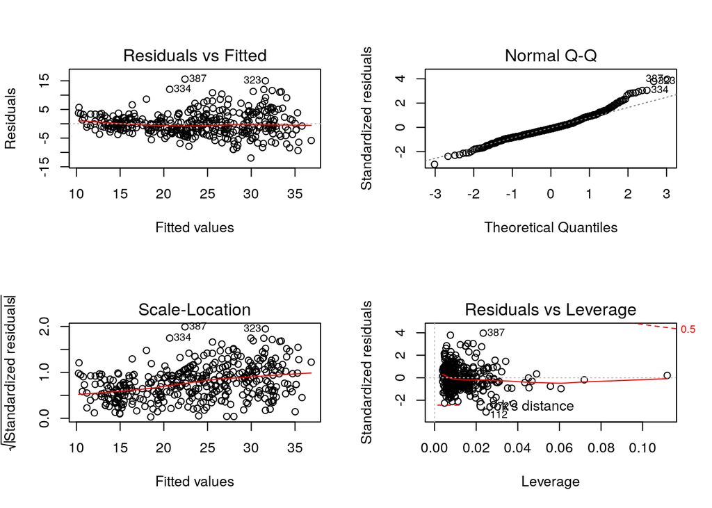

```r
par(mfrow=c(2,2))
plot(lm.fit)
```

Since all three significant variables display relationships to `mpg` that appear roughly logarithmic, another idea is to try transforming the response instead of the predictors:

```r
lm.fit.log.response = lm(log(mpg) ~ .-name, data=Auto)
summary(lm.fit.log.response)
```

```
##
## Call:
## lm(formula = log(mpg) ~ . - name, data = Auto)
##
## Residuals:
##      Min       1Q   Median       3Q      Max
## -0.40955 -0.06533  0.00079  0.06785  0.33925
##
## Coefficients:
##                Estimate Std. Error t value Pr(>|t|)
## (Intercept)   1.751e+00  1.662e-01  10.533  < 2e-16 ***
## cylinders    -2.795e-02  1.157e-02  -2.415  0.01619 *
## displacement  6.362e-04  2.690e-04   2.365  0.01852 *
## horsepower   -1.475e-03  4.935e-04  -2.989  0.00298 **
## weight       -2.551e-04  2.334e-05 -10.931  < 2e-16 ***
## acceleration -1.348e-03  3.538e-03  -0.381  0.70339
## year          2.958e-02  1.824e-03  16.211  < 2e-16 ***
## origin        4.071e-02  9.955e-03   4.089 5.28e-05 ***
## ---
## Signif. codes:  0 '***' 0.001 '**' 0.01 '*' 0.05 '.' 0.1 ' ' 1
##
## Residual standard error: 0.1191 on 384 degrees of freedom
## Multiple R-squared:  0.8795, Adjusted R-squared:  0.8773
## F-statistic: 400.4 on 7 and 384 DF,  p-value: < 2.2e-16
```